# 분해법

### **0. 환경설정**

```r
library(forecast)
library(TTR)
library(lmtest)
```

### **예제1**

**[데이터 호출]** 월별 음식물 출하지수

```r
z <- scan("C:\\R-Project\\DAT\\Time Series Data\\food.txt")
t <- 1:length(z)
food <- ts(z, start=c(1981,1), frequency=12)

food
```

```
##        Jan   Feb   Mar   Apr   May   Jun   Jul   Aug   Sep   Oct   Nov   Dec
## 1981  44.3  40.0  41.9  43.5  46.0  45.1  43.9  44.5  43.3  43.9  42.8  47.8
## 1982  39.8  36.1  43.7  48.8  50.4  48.0  46.8  51.0  47.1  43.6  41.6  47.0
## 1983  37.9  38.9  46.5  51.6  54.8  52.9  50.3  51.9  57.2  49.9  49.4  54.5
## 1984  46.9  47.5  52.7  57.3  63.4  61.1  59.0  61.7  62.5  57.2  54.5  60.3
## 1985  54.6  49.4  57.6  60.7  66.0  62.6  61.8  66.3  62.6  59.8  59.0  64.9
## 1986  57.8  57.0  63.0  64.7  68.3  62.8  63.3  66.5  69.7  64.7  64.4  72.5
## 1987  65.8  60.1  71.3  72.9  77.5  70.8  73.9  74.9  75.8  74.0  70.8  79.0
## 1988  70.2  67.3  76.5  81.6  85.4  84.7  82.3  81.3  72.2  84.5  82.9  89.3
## 1989  83.1  78.8  89.6  91.1  96.1  95.2  89.4  94.5  94.0  88.8  86.0  81.2
## 1990  90.2  78.1  94.9  96.0 100.2  97.3  90.8 105.6  99.3  91.5  90.2  94.7
## 1991  87.7  84.4  89.8  97.9 104.4 102.1  99.3 109.2 115.9  98.6 100.3 101.5
## 1992  99.0  89.0 102.0 111.2 114.6 106.8 110.9 119.9 113.4 111.9 106.0 111.2
```

**[시도표]** 월별 음식물 출하지수

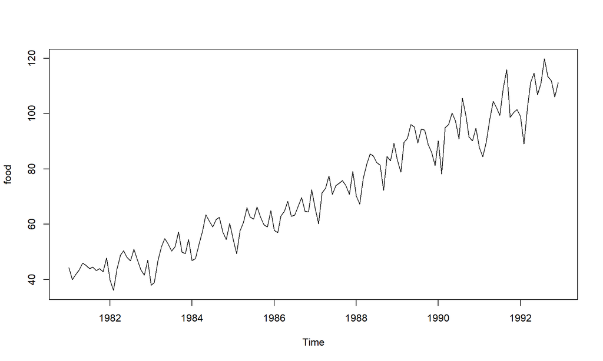

```r
plot.ts(food)
```

**[데이터 변환]** 로그변환 후 시도표

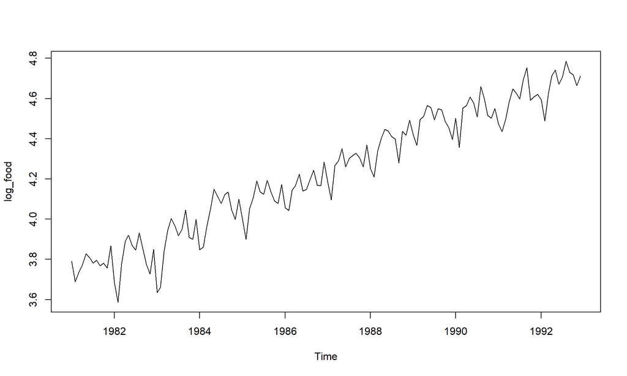

```r
log_food <- log(food)
plot.ts(log_food)
```

**[분해법]** 추세성분 추정 : Zt = beta_0 + beta_1t+epsilon_t

```r
fit <- lm(log_food ~ t )
summary(fit)
```

```
##
## Call:
## lm(formula = log_food ~ t)
##
## Residuals:
##       Min        1Q    Median        3Q       Max
## -0.251154 -0.042190  0.009368  0.051058  0.147910
##
## Coefficients:
##             Estimate Std. Error t value Pr(>|t|)
## (Intercept) 3.705715   0.012870  287.94   <2e-16 ***
## t           0.007216   0.000154   46.86   <2e-16 ***
## ---
## Signif. codes:  0 '***' 0.001 '**' 0.01 '*' 0.05 '.' 0.1 ' ' 1
##
## Residual standard error: 0.07682 on 142 degrees of freedom
## Multiple R-squared:  0.9393, Adjusted R-squared:  0.9388
## F-statistic:  2195 on 1 and 142 DF,  p-value: < 2.2e-16
```

**[분해법]** 추정된 추세 성분: hat(T_t) = 3.705715+0.007216t

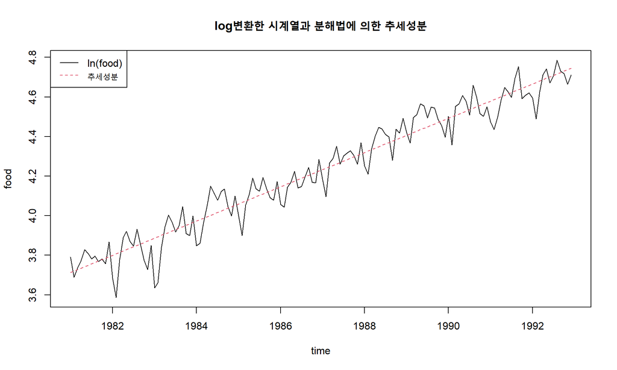

```r
trend <- fitted(fit)
ts.plot(log_food, trend, col=1:2, lty=1:2, ylab="food", xlab="time",
        main="log변환한 시계열과 분해법에 의한 추세성분")
legend("topleft", lty=1:2, col=1:2, c("ln(food)", "추세성분"))
```

**[분해법]** 계절성분 추정 : Zt-hat(T_t) = sum(i=1,…,12) (delta_i * IND_ti) +epsilon_t

```r
adjtrend = log_food-trend  # Zt-hat(T_t)
y = factor(cycle(adjtrend)) # 지시함수 생성

fit1 <- lm(adjtrend ~ 0+y) #상수항이 없는 계절모형 생성
summary(fit1)
```

```
##
## Call:
## lm(formula = adjtrend ~ 0 + y)
##
## Residuals:
##       Min        1Q    Median        3Q       Max
## -0.182321 -0.028501  0.000597  0.025663  0.146887
##
## Coefficients:
##     Estimate Std. Error t value Pr(>|t|)
## y1  -0.06883    0.01423  -4.837 3.61e-06 ***
## y2  -0.13853    0.01423  -9.735  < 2e-16 ***
## y3  -0.01290    0.01423  -0.907 0.366289
## y4   0.03840    0.01423   2.699 0.007872 **
## y5   0.08825    0.01423   6.201 6.69e-09 ***
## y6   0.03871    0.01423   2.720 0.007401 **
## y7   0.01061    0.01423   0.746 0.457221
## y8   0.05972    0.01423   4.197 4.94e-05 ***
## y9   0.03776    0.01423   2.653 0.008945 **
## y10 -0.01856    0.01423  -1.304 0.194518
## y11 -0.05041    0.01423  -3.542 0.000549 ***
## y12  0.01577    0.01423   1.108 0.269816
## ---
## Signif. codes:  0 '***' 0.001 '**' 0.01 '*' 0.05 '.' 0.1 ' ' 1
##
## Residual standard error: 0.0493 on 132 degrees of freedom
## Multiple R-squared:  0.6172, Adjusted R-squared:  0.5824
## F-statistic: 17.73 on 12 and 132 DF,  p-value: < 2.2e-16
```

**[분해법]** 추정된 계절 성분 hat(S_t) (1월 : hat(S_t)=-0.06883, 8월 : hat(S_t)=0.05972)

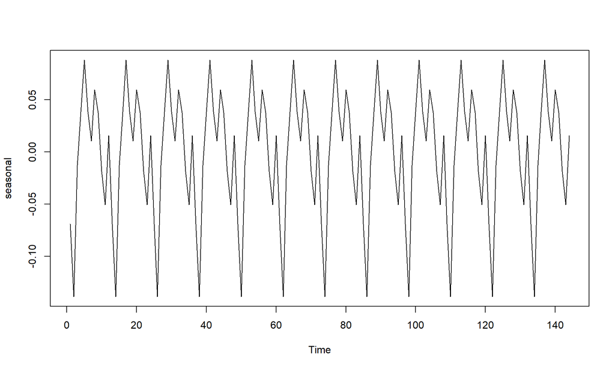

```r
seasonal <- fitted(fit1)
ts.plot(seasonal)
```

**[분해법]** 추정값 : hat(Z_t) = hat(T_t)+hat(S_t)

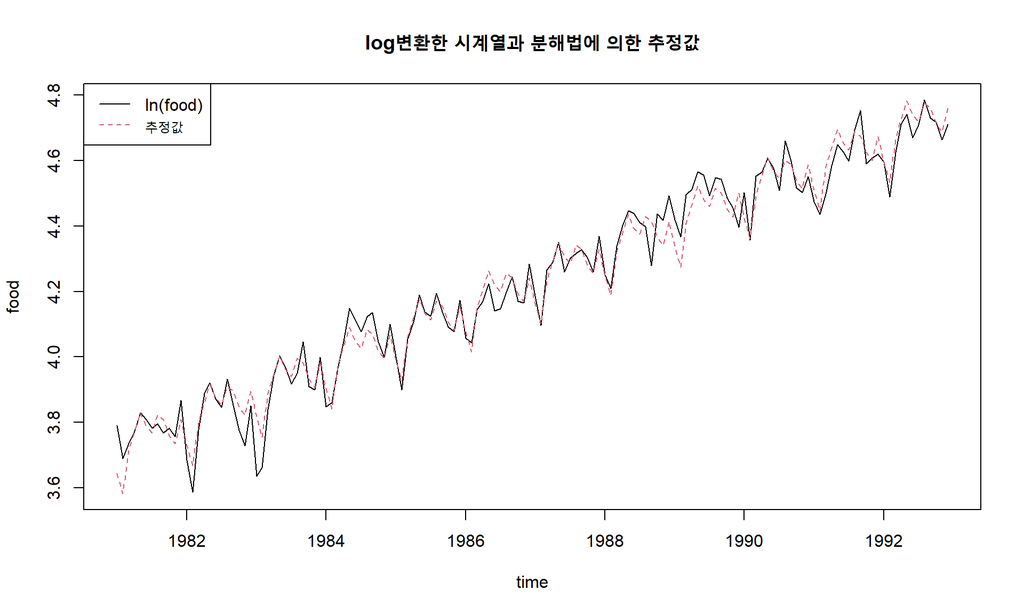

```r
pred <- trend + seasonal
ts.plot(log_food, pred, col=1:2, lty=1:2, ylab="food", xlab="time",
        main="log변환한 시계열과 분해법에 의한 추정값")
legend("topleft", lty=1:2, col=1:2, c("ln(food)", "추정값"))
```

**[분해법]** 잔차검토

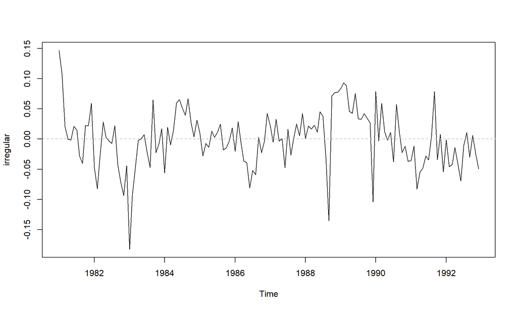

```r
irregular <- log_food - pred
ts.plot(irregular); abline(h=0, lty=2, col='grey')
```

**[분해법]** 잔차검토

```r
dwtest(lm(irregular~ 1))
```

```
##
##  Durbin-Watson test
##
## data:  lm(irregular ~ 1)
## DW = 1.0803, p-value = 1.374e-08
## alternative hypothesis: true autocorrelation is greater than 0
```